# Project Reference– Operation Come to School

2023-11-23

# Admin level 1

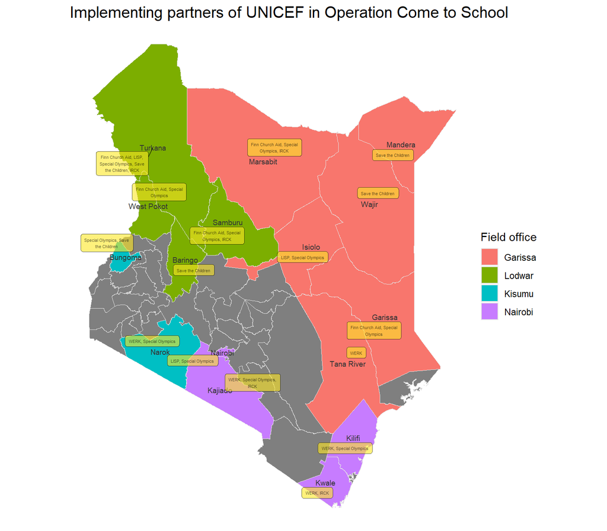

Download map [here](https://github.com/kenya-eie-wg/operation_come_to_school_public/blob/main/img/implementing_partner_adm1_map.png)

# Admin level 2

## Constituency-level targets

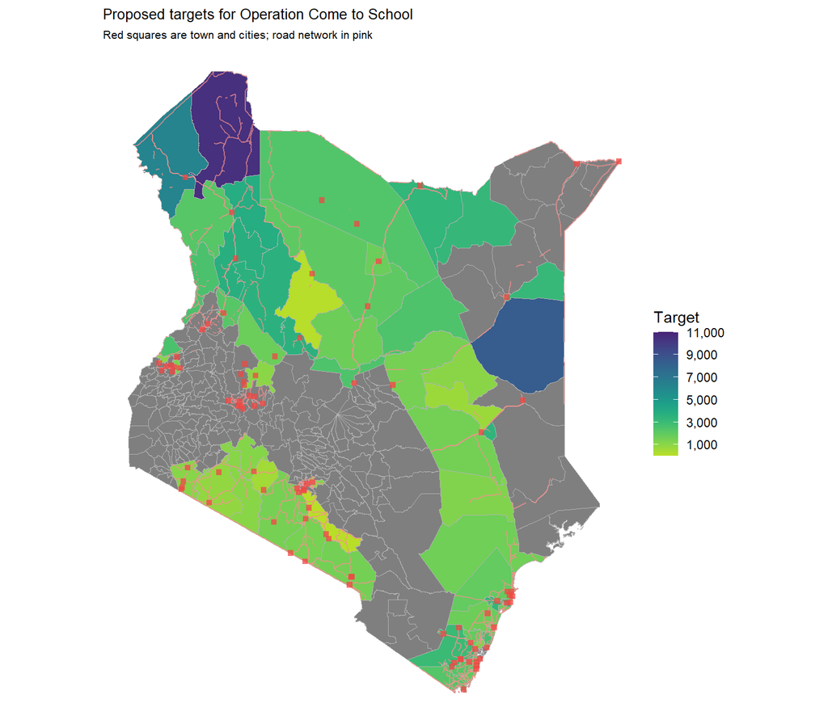

## Coverage of implementing partners

[figure not shown]

# Targets

## County-level targets

Only Save the Children has been able to provide county-level targets. All other partners have only provided an overall target for the project. As no targeting methodology has been provided, targets have been provisionally allocated based on the share of the number of poor persons per county. Poverty incidence may be found [here](https://statistics.knbs.or.ke/nada/index.php/catalog/123/download/579) and county populations originate from the [census](https://github.com/Shelmith-Kariuki/rKenyaCensus).

As with the constituency-level targets below, it is best to confirm these allocations with partners and make any necessary adjustments to the [main file](https://github.com/kenya-eie-wg/operation_come_to_school_public/blob/main/data/adm2_targets.csv).

Targets and population by county

| fo | county | population | children_0_17 | combined_target | werk_target | fca_target | lisp_target | irck_target | so_target |
| --- | --- | --- | --- | --- | --- | --- | --- | --- | --- |
| Garissa | Garissa | 835,482 | 460,362 | 5,110 | 0 | 5,110 | 0 | 0 | 0 |
| Garissa | Isiolo | 267,997 | 141,796 | 3,915 | 0 | 0 | 3,915 | 0 | 0 |
| Garissa | Mandera | 862,079 | 547,776 | 0 | 0 | 0 | 0 | 0 | 0 |
| Garissa | Marsabit | 447,150 | 254,103 | 9,422 | 0 | 9,050 | 0 | 372 | 0 |
| Garissa | Tana River | 314,710 | 173,924 | 4,361 | 4,361 | 0 | 0 | 0 | 0 |
| Garissa | Wajir | 775,302 | 459,863 | 14,717 | 0 | 0 | 0 | 0 | 0 |
| Kisumu | Bungoma | 1,739,059 | 882,499 | 4,963 | 0 | 0 | 0 | 0 | 0 |
| Kisumu | Narok | 1,149,347 | 647,524 | 4,646 | 4,646 | 0 | 0 | 0 | 0 |
| Lodwar | Baringo | 662,760 | 349,005 | 2,714 | 0 | 0 | 0 | 0 | 0 |
| Lodwar | Samburu | 307,957 | 175,238 | 5,400 | 0 | 4,901 | 0 | 499 | 0 |
| Lodwar | Turkana | 922,210 | 495,492 | 29,994 | 0 | 12,671 | 6,101 | 718 | 0 |
| Lodwar | West Pokot | 435,634 | 259,796 | 4,766 | 0 | 4,766 | 0 | 0 | 0 |
| Nairobi | Kajiado | 1,107,296 | 494,149 | 8,574 | 8,360 | 0 | 0 | 214 | 0 |
| Nairobi | Kilifi | 1,440,958 | 721,922 | 14,489 | 14,489 | 0 | 0 | 0 | 0 |
| Nairobi | Kwale | 858,748 | 448,395 | 9,560 | 8,864 | 0 | 0 | 697 | 0 |
| Nairobi | Nairobi | 3,713,610 | 1,538,589 | 9,026 | 0 | 0 | 9,026 | 0 | 0 |

## Constituency-level targets

Targets at the constituency level (admin level 2) have been allocated based on the same methodology as above, with targets being in line with each constituency’s share of poor persons. However, additional refinement is probably warranted since poverty incidence was only available at the county level, meaning that the number of poor persons per constituency was calculated based on the constituency population and the county-level poverty incidence.

|  | county | constituency | partners | population | children_0_17 | target | adm2_pcode |
| --- | --- | --- | --- | --- | --- | --- | --- |
| 1 | Kwale | Msambweni | IRCK, WERK | 173213 | 75831 | 2002 | KE002007 |
| 2 | Kwale | Lunga Lunga | IRCK, WERK | 198195 | 110173 | 2290 | KE002008 |
| 3 | Kwale | Matuga | IRCK, WERK | 192999 | 95721 | 2230 | KE002009 |
| 4 | Kwale | Kinango | WERK | 294341 | 166670 | 3038 | KE002010 |
| 5 | Kilifi | Kilifi North | Special Olympics, WERK | 177527 | 83972 | 1785 | KE003011 |
| 6 | Kilifi | Kilifi South | Special Olympics, WERK | 266209 | 125327 | 2677 | KE003012 |
| 7 | Kilifi | Kaloleni | Special Olympics, WERK | 192905 | 100438 | 1940 | KE003013 |
| 8 | Kilifi | Rabai | Special Olympics, WERK | 120479 | 57069 | 1211 | KE003014 |
| 9 | Kilifi | Ganze | Special Olympics, WERK | 166203 | 93756 | 1671 | KE003015 |
| 10 | Kilifi | Malindi | Special Olympics, WERK | 326991 | 155835 | 3288 | KE003016 |

[output cut: 84 more lines]

Download the targets [here](https://github.com/kenya-eie-wg/operation_come_to_school_public/blob/main/data/adm2_targets.csv), with the raw version [here](https://raw.githubusercontent.com/kenya-eie-wg/operation_come_to_school_public/main/data/adm2_targets.csv).

## Additional notes for reporting staff

These are the areas that need additional clarification from field offices and partners:

- Please refer to the list of locations to see how sub-counties have been matched to constituencies.
- Please review preliminary allocations with implementing partners.
- Special Olympics to provide detailed targets

# Maps for field offices

All maps in this section may be found [here](https://github.com/kenya-eie-wg/operation_come_to_school_public/tree/main/img).

## Garissa FO

### Garissa

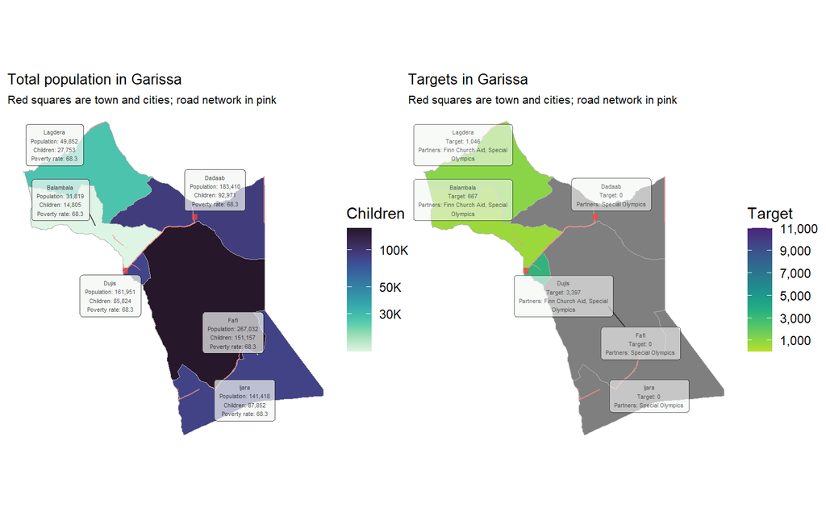

### Isiolo

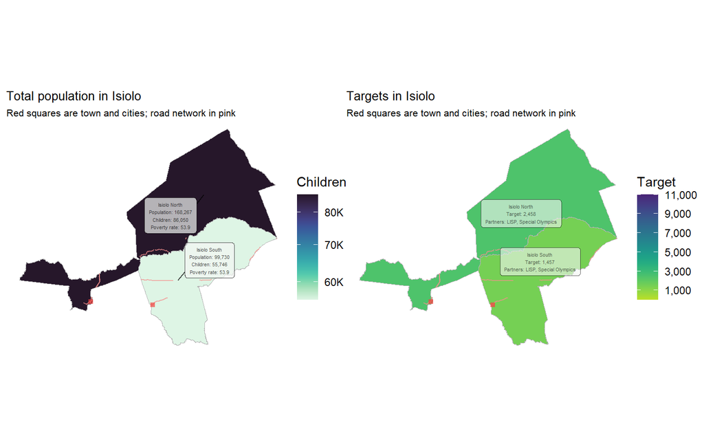

### Marsabit

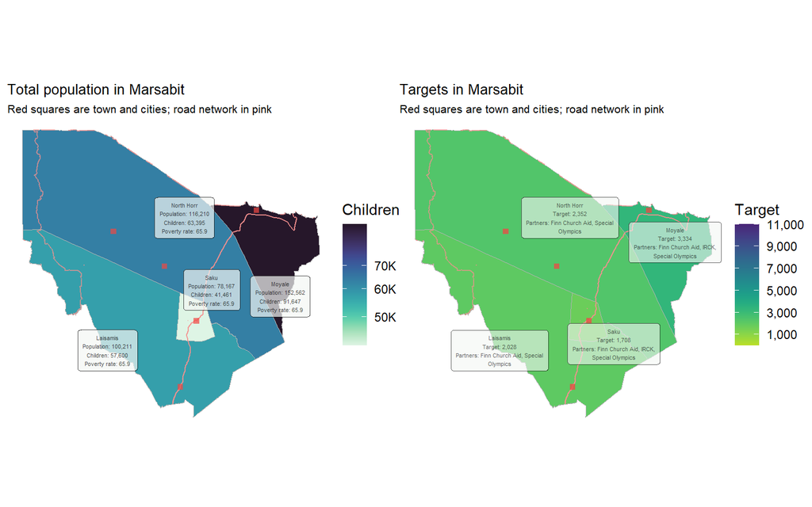

### Tana River

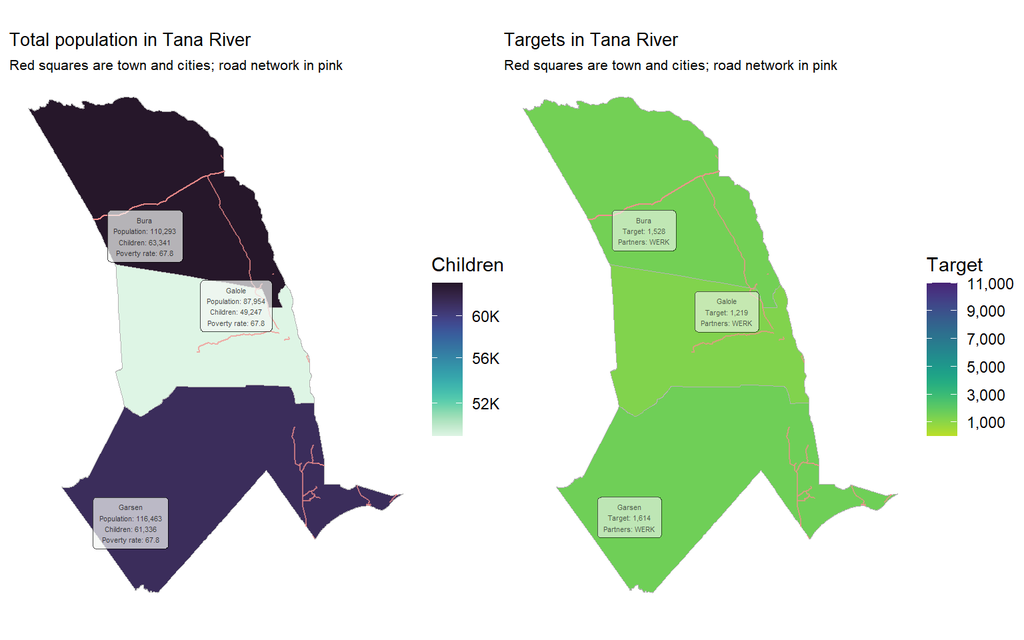

### Wajir

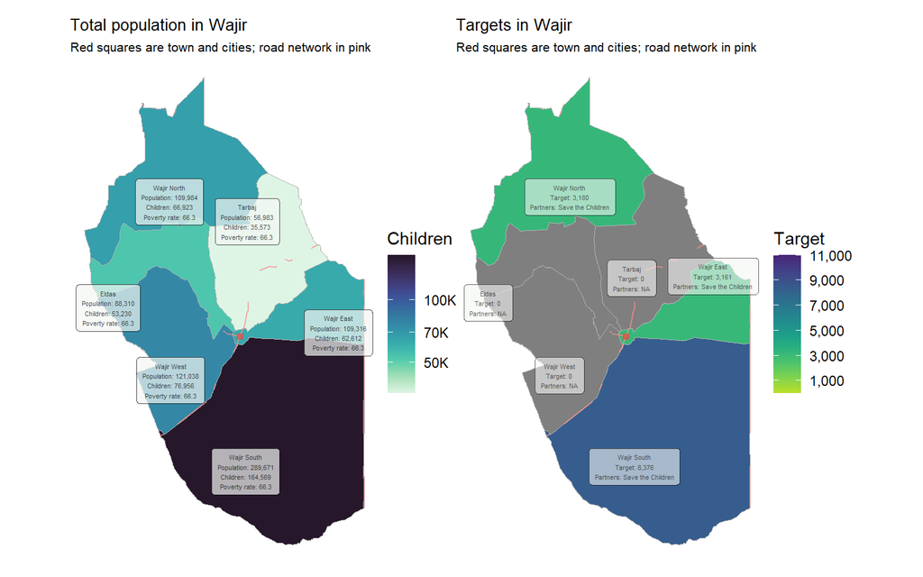

## Kisumu FO

### Bungoma

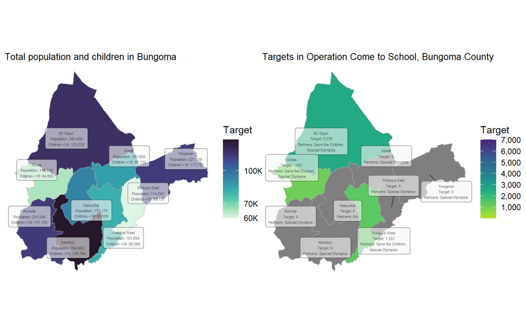

### Narok

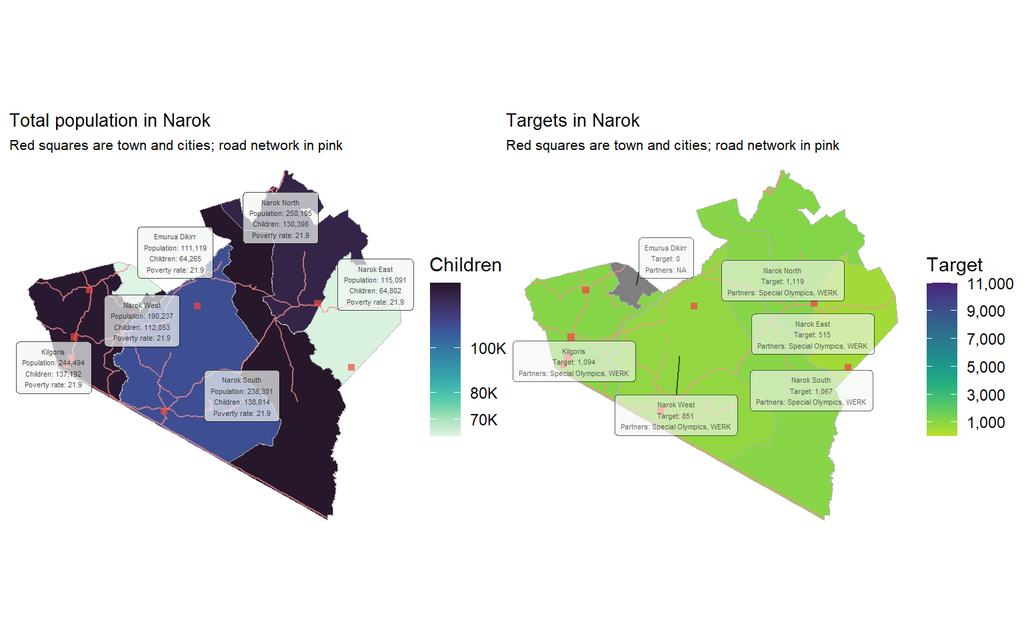

## Lodwar FO

### Baringo

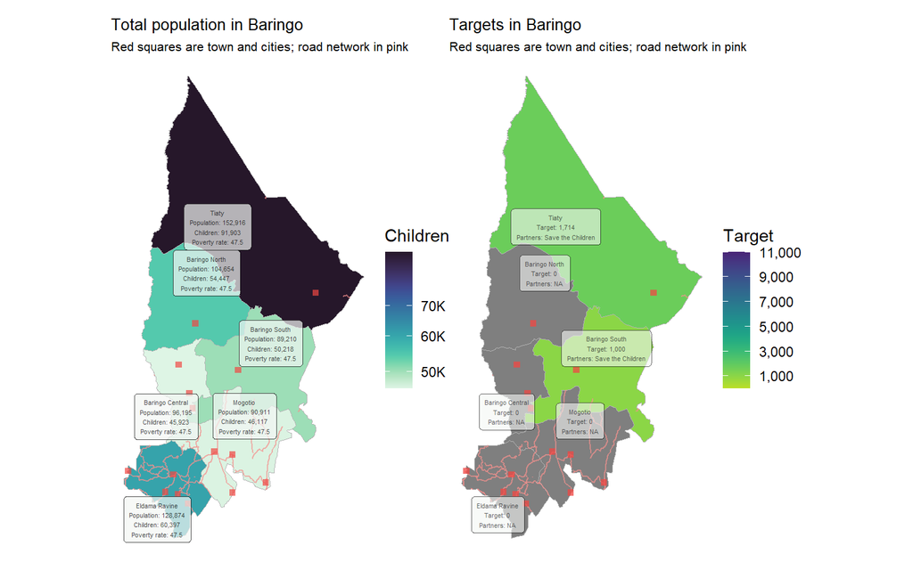

### Samburu

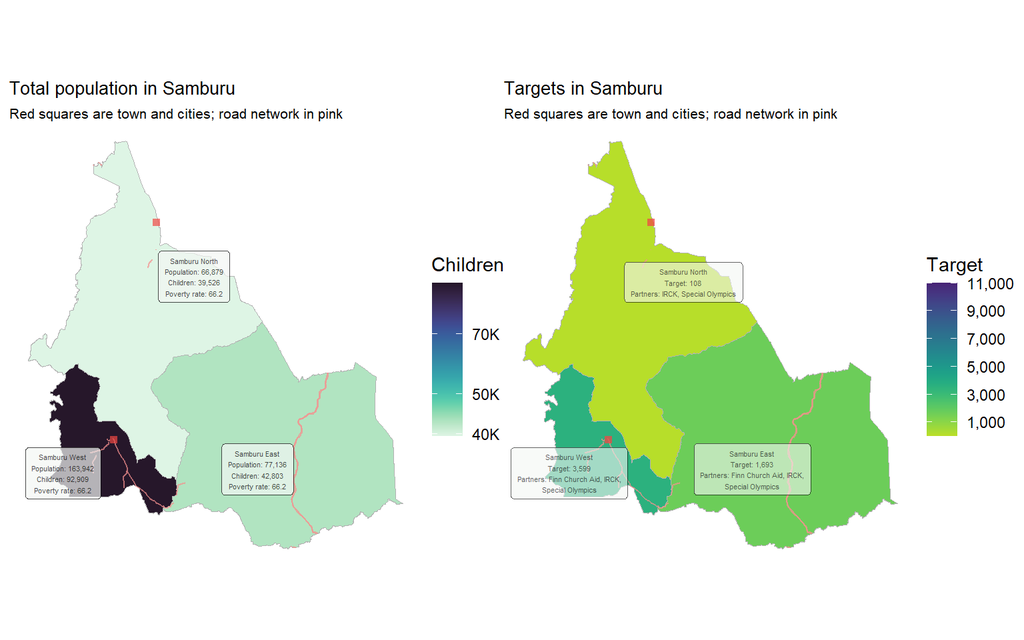

### Turkana

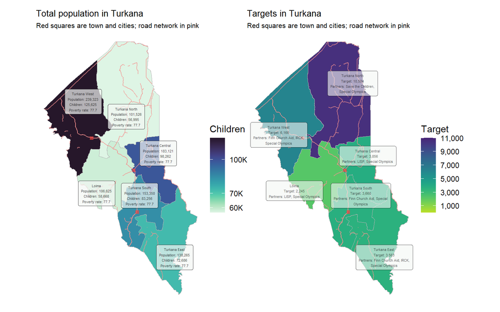

### West Pokot

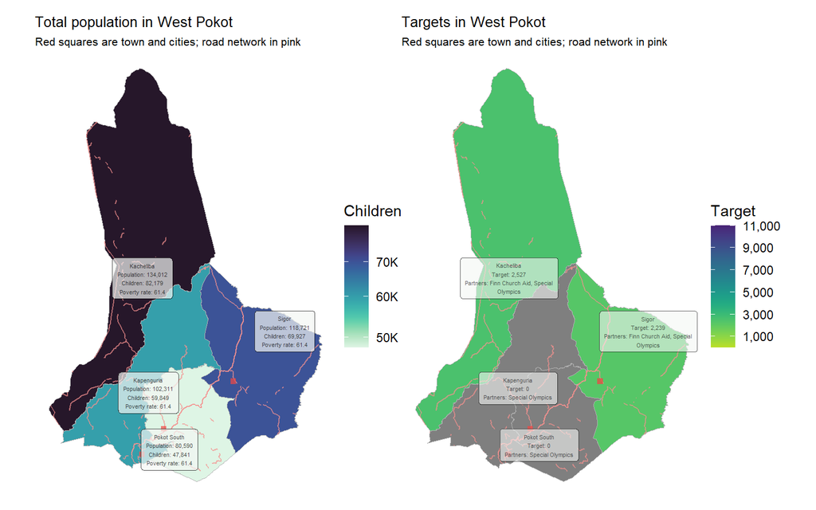

## Nairobi FO

### Kajiado

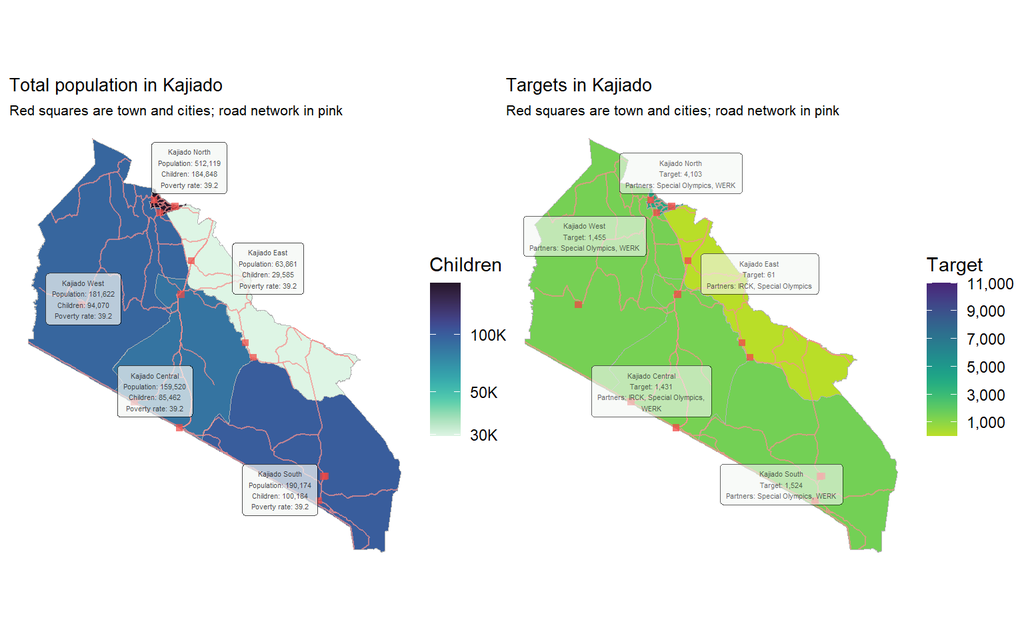

### Kilifi

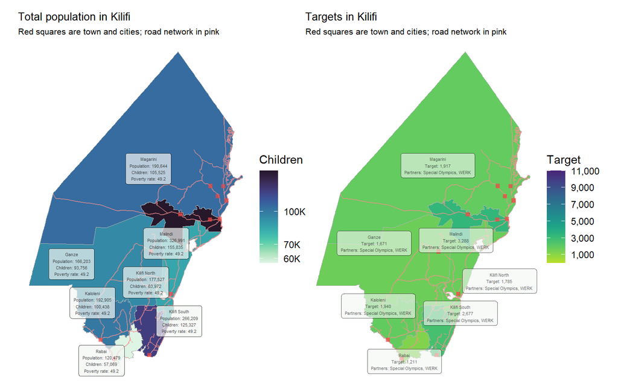

### Kwale

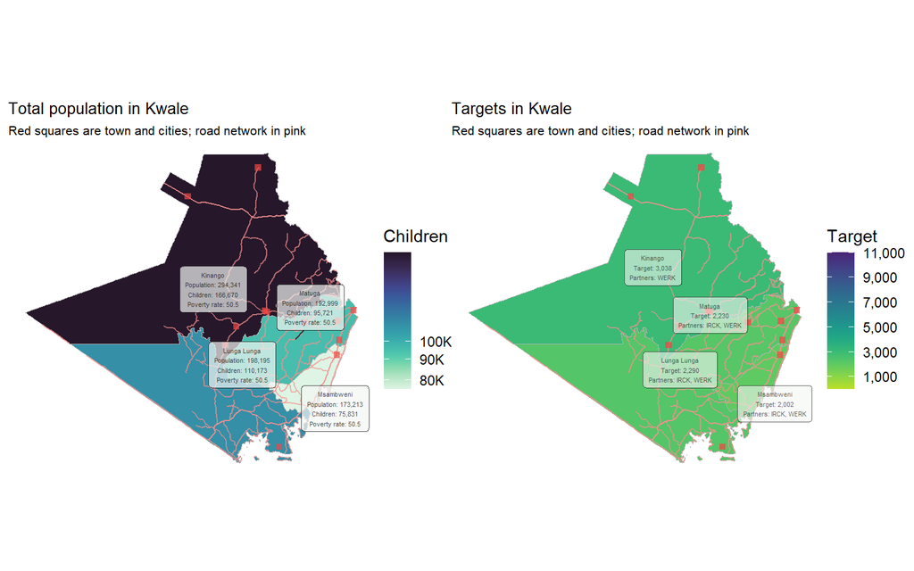

### Nairobi

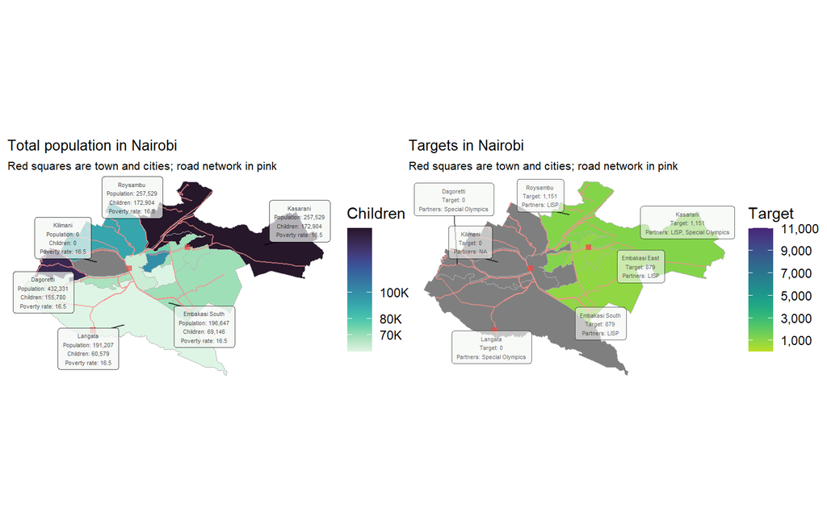

# Contact lists

Request access from tmito@unicef.org for contact list for this project.